# Full Report

65090502414 ธนวินท์ แสงวิสุทธิ์ 65090502417 ปิยพัทธ์ จันทร์ทวี

2025-05-28

## Load and Prepare the Data

#### ชุดข้อมูล IBM HR Analytics มีจำนวนข้อมูล 1058 คน โดยมีทั้งข้อมูลเชิงปริมาณและเชิงคุณภาพ ซึ่งครอบคลุมข้อมูลเกี่ยวกับอายุ ระยะเวลาการทำงาน ความพึงพอใจในงาน รายได้ และอื่น ๆ ลบตัวแปรที่ไม่มีความแปรปรวน (เช่น Over18, StandardHours, EmployeeCount, Employee Number) ออกจากชุดข้อมูล

```r
ibm <- read.csv("IBM train.csv")
sum(is.na(ibm))
```

```
## [1] 0
```

```r
str(ibm)
```

```
## 'data.frame':    1058 obs. of  35 variables:
##  $ Age                     : int  41 49 37 33 27 32 59 30 38 36 ...
##  $ Attrition               : int  1 0 1 0 0 0 0 0 0 0 ...
##  $ BusinessTravel          : chr  "Travel_Rarely" "Travel_Frequently" "Travel_Rarely" "Travel_Frequently" ...
##  $ DailyRate               : int  1102 279 1373 1392 591 1005 1324 1358 216 1299 ...
##  $ Department              : chr  "Sales" "Research & Development" "Research & Development" "Research & Development" ...
##  $ DistanceFromHome        : int  1 8 2 3 2 2 3 24 23 27 ...
##  $ Education               : int  2 1 2 4 1 2 3 1 3 3 ...
##  $ EducationField          : chr  "Life Sciences" "Life Sciences" "Other" "Life Sciences" ...
##  $ EmployeeCount           : int  1 1 1 1 1 1 1 1 1 1 ...
##  $ EmployeeNumber          : int  1 2 4 5 7 8 10 11 12 13 ...
##  $ EnvironmentSatisfaction : int  2 3 4 4 1 4 3 4 4 3 ...
##  $ Gender                  : chr  "Female" "Male" "Male" "Female" ...
##  $ HourlyRate              : int  94 61 92 56 40 79 81 67 44 94 ...
##  $ JobInvolvement          : int  3 2 2 3 3 3 4 3 2 3 ...
```

[output cut: 21 more lines]

```r
colnames(ibm)
```

```
##  [1] "Age"                      "Attrition"
##  [3] "BusinessTravel"           "DailyRate"
##  [5] "Department"               "DistanceFromHome"
##  [7] "Education"                "EducationField"
##  [9] "EmployeeCount"            "EmployeeNumber"
## [11] "EnvironmentSatisfaction"  "Gender"
## [13] "HourlyRate"               "JobInvolvement"
## [15] "JobLevel"                 "JobRole"
## [17] "JobSatisfaction"          "MaritalStatus"
## [19] "MonthlyIncome"            "MonthlyRate"
## [21] "NumCompaniesWorked"       "Over18"
## [23] "OverTime"                 "PercentSalaryHike"
## [25] "PerformanceRating"        "RelationshipSatisfaction"
## [27] "StandardHours"            "StockOptionLevel"
## [29] "TotalWorkingYears"        "TrainingTimesLastYear"
## [31] "WorkLifeBalance"          "YearsAtCompany"
## [33] "YearsInCurrentRole"       "YearsSinceLastPromotion"
## [35] "YearsWithCurrManager"
```

```r
# Remove non-informative columns
ibm <- ibm[,-c(9,10,22,27)]

# Separate categorical and numeric variables
ibm_cate <- ibm[,c('BusinessTravel', 'Department', 'EducationField', 'Gender', 'JobRole', 'MaritalStatus', 'OverTime')]
ibm_num <- ibm[,c('Age', 'Attrition', 'DailyRate', 'DistanceFromHome', 'Education',
                  'EnvironmentSatisfaction', 'HourlyRate', 'JobInvolvement', 'JobLevel', 'JobSatisfaction',
                  'MonthlyIncome', 'MonthlyRate', 'NumCompaniesWorked', 'PercentSalaryHike', 'PerformanceRating',
                  'RelationshipSatisfaction', 'StockOptionLevel', 'TotalWorkingYears', 'TrainingTimesLastYear',
                  'WorkLifeBalance', 'YearsAtCompany', 'YearsInCurrentRole', 'YearsSinceLastPromotion',
                  'YearsWithCurrManager')]
dim(ibm)
```

```
## [1] 1058   31
```

## Train/Test Split and One-hot Encoding

#### แบ่งข้อมูลออกเป็น training set 80% และ test set 20% และแปลงข้อมูลประเภท categorical ด้วย model.matrix()

```r
ibm$Attrition <- as.factor(ibm$Attrition)

set.seed(2417)
train_idx <- sample(1:dim(ibm)[1], size = 0.8*dim(ibm)[1])
ibm_train <- ibm[train_idx, ]
ibm_test <- ibm[-train_idx, ]

ibm_mat <- model.matrix(Attrition~., data = ibm_train)
ibm_mat_att <- data.frame(Attrition = as.factor(ibm_train$Attrition), ibm_mat[,-1])

test_mat <- model.matrix(Attrition~., data = ibm_test)
mat_test <- data.frame(Attrition = as.factor(ibm_test$Attrition), test_mat[,-1])

dim(ibm_mat_att)
```

```
## [1] 846  45
```

```r
dim(mat_test)
```

```
## [1] 212  45
```

```r
table(ibm_mat_att$Attrition)
```

```
##
##   0   1
## 709 137
```

```r
table(mat_test$Attrition)
```

```
##
##   0   1
## 170  42
```

## Balance the Dataset with BLSMOTE

#### จากการที่จุดประสงค์คือการสร้างตัวแบบที่ใช้ในทำนายการลาออกของพนักงานจึงใช้ BLSMOTE ในการแก้ไขความไม่สมดุลของ ตัวแปร target(ในที่นี้คือการลาออกของพนักงาน “Attrition”) และใช้ชุดข้อมูลการ smote ปรับให้เข้ากับ argument ของ function ในแต่ละ model

```r
sm <- BLSMOTE(ibm_mat_att[,-1], ibm_mat_att$Attrition, K = 7 , C = 3)
```

```
## [1] "Borderline-SMOTE done"
```

```r
smt <- sm$data

table(smt$class)
```

```
##
##   0   1
## 709 676
```

```r
smt_rf <- smt
smt_rf$class <- as.factor(smt_rf$class)

smt_xg <- smt
smt_xg$class <- ifelse(as.numeric(as.character(smt_xg$class)) == 1, 1, 0)

smt_logis <- smt
smt_logis$class <- as.factor(smt_logis$class)
```

# ——————–

## สร้างตัวแบบเพื่อใช้ในการหาตัวแบบที่ดีที่สุดในการทำนายการลาออก

# ——————–

Performance Results ## เทียบผลทุกตัวแบบด้วยการพิจารณา F1-Score เนื่องจาก จุดประสงค์คือการได้มาซึ่งการทำนายผู้ที่มีแนวโน้มที่จะลาออก และตัวแปรที่มีอิทธิพล จึงจะเลือก ตัวแบบที่ให้ผลทั้งในด้านความสามารถในการจับตัวแบบ หรือ Precision (จากการทำนายว่าลาออก เป็นผู้ที่ลาออกอยู่จริงอยู่สัดส่วนเท่าใด) และ ในด้านความถูกต้องของการทำนาย หรือ Recall (จากข้อมูลผู้ลาออกจริงทั้งหมด เป็นผู้ที่ลาออกอยู่จริงเป็นสัดส่วนเท่าใด) ## ด้วยเหตุนี้จึงเลือก พิจารณา ค่า F1-Score ที่เป็นค่าที่ให้ความสำคัญกับทั้ง Precision และ Recall ## ได้ว่า Random Forest ให้ค่า F1-Scorwe ที่มากที่สุด

```r
rf_result
```

```
##   Accuracy Precision    Recall  F1_Score
## 1 0.931769 0.8961959 0.9815291 0.9368408
```

```r
xgb_result
```

```
##    Accuracy Precision    Recall  F1_Score
## 1 0.9270758  0.907527 0.9553288 0.9307348
```

```r
logi_results
```

```
##   SubsetMethod  Accuracy Precision    Recall  F1_Score
## 1         full 0.8664260 0.9100290 0.8259202 0.8657559
## 2      forward 0.8570397 0.9044594 0.8126678 0.8559055
## 3     backward 0.8649819 0.9082961 0.8246134 0.8643972
## 4     stepwise 0.8592058 0.9036199 0.8180561 0.8585298
```

```r
best_model <-rf_cv(mat_test, "Attrition")
best_model
```

```
##    Accuracy Precision    Recall  F1_Score
## 1 0.7511628  0.771841 0.9615484 0.8549823
```

## Feature Importance

### จากการที่ประสิทธิภาพของ Random Forest และ XGBoost อยู่ในระดับที่ใกล้เคียงกัน จึงจะนำ Feature ที่สำคัญจากทั้ง 2 ตัวแบบมาใช้ในการคัดเลือกตัวแปรที่มีอิทธิพลต่อการลาออกของพนักงาน IBM

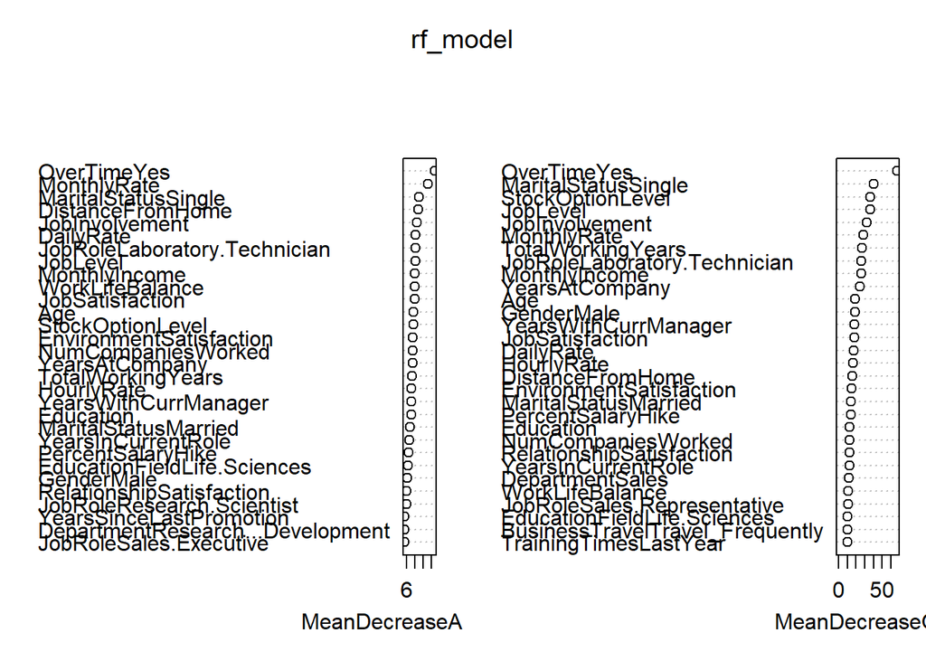

```r
varImpPlot(rf_model)
```

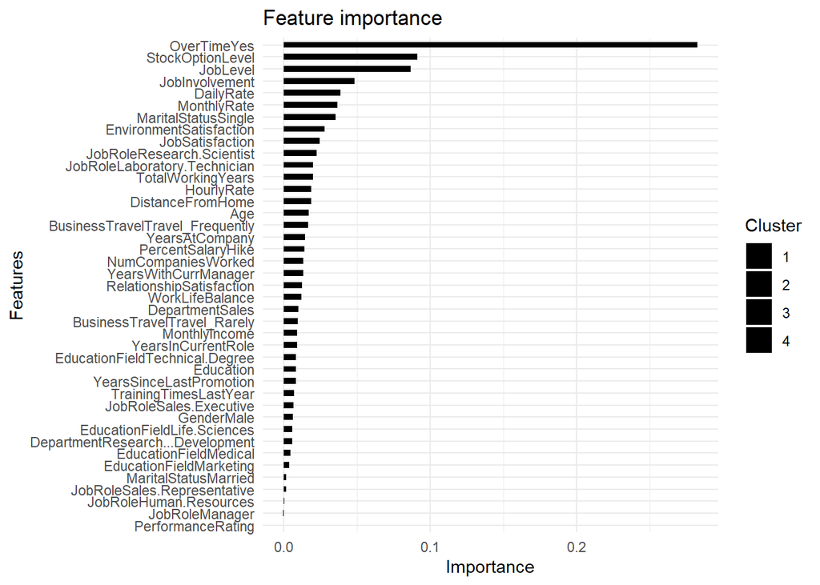

```r
xgb.ggplot.importance(xgb_imp) + scale_fill_manual(values = rep("black", nrow(xgb_imp))) + theme_minimal()
```

## Clustering Based on Important Features

```r
# Select top features
top_xgb <- head(xgb_imp$Feature, 10)

imp_rf <- importance(rf_model)
top_rf <- rownames(imp_rf[order(imp_rf[, 1], decreasing = TRUE), ])[1:10]

# จัดเรียงเฉพาะตาม MeanDecreaseAccuracy ของ class "1"
top_rf <- rownames(imp_rf[order(imp_rf[, "1"], decreasing = TRUE), ])[1:5]
top_rf
```

```
## [1] "OverTimeYes"     "MonthlyRate"     "WorkLifeBalance" "DailyRate"
## [5] "JobSatisfaction"
```

```r
selected_features <- union(top_rf,top_xgb)
selected_features
```

```
##  [1] "OverTimeYes"               "MonthlyRate"
##  [3] "WorkLifeBalance"           "DailyRate"
##  [5] "JobSatisfaction"           "StockOptionLevel"
##  [7] "JobLevel"                  "JobInvolvement"
##  [9] "MaritalStatusSingle"       "EnvironmentSatisfaction"
## [11] "JobRoleResearch.Scientist"
```

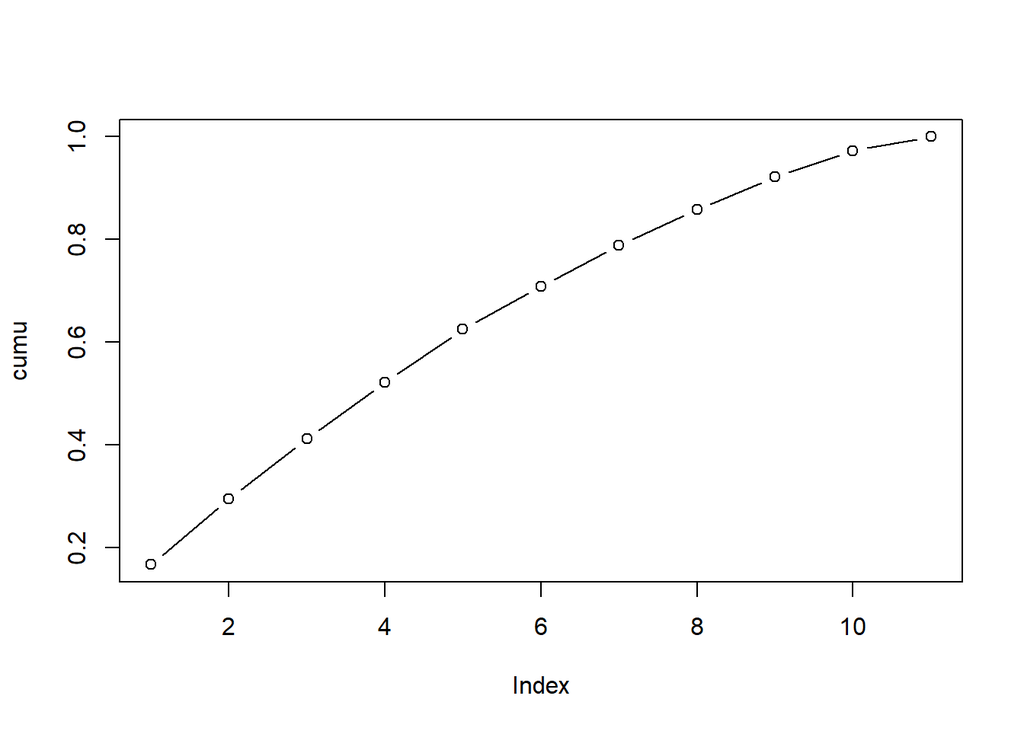

```r
data_clustering <- mat_test[, selected_features]
data_scaled <- scale(data_clustering)
pca_res <- prcomp(data_scaled, center = TRUE, scale. = TRUE)
pca_var <- pca_res$sdev ^ 2
cumu <- cumsum(pca_var/sum(pca_var))
plot(cumu, type ="b")
```

```r
best_pc <- which(cumu > 0.8)

pca_data <- as.data.frame(pca_res$x[, 1:best_pc])
```

## อธิบายแต่ละตัวแปรที่อาจมีอิทธิพลต่อการลาออกของพนักงาน

“OverTimeYes” พนักงานทำงานล่วงเวลา (แสดงถึงการทุ่มเทแรงและเวลาให้กับการทำงานและบริษัท)

“MonthlyRate” รายได้รายเดือนพนักงาน (ในบริบทขอผู้ที่มีแนวโน้มจะลาออก อาจมีปัจจัยมาจากด้านรายได้ เนื่องจาก เงินถือเป็นปัจจัยที่สำคัญต่อการดำเนินชีวิต)

“JobInvolvement” ความมีส่วนร่วมกับงาน (ในบริบทขอผู้ที่มีแนวโน้มจะลาออก อาจขาดส่วนร่วมกับงานที่ทำหรือได้รับมอบหมาย กล่าวคือขาดแรงจูงใจและอารมณ์ร่วมกับงาน)

“DailyRate” รายได้รายวัน

“JobSatisfaction” ความพึงพอใจกับงาน (ในบริบทขอผู้ที่มีแนวโน้มจะลาออก อาจเป็นผู้ที่ไม่ได้พึงพอใจกับงานที่ได้รับ อาจเป็นลักษณะเนื้องาน หรือสายงานที่ไม่ตรงตามความถนัด)

“StockOptionLevel” ระดับการถือหุ้นในองค์กร (ในบริบทของเงินว่าจ้างในอเมริกาของบริษัทใหญ่ เงินเดือนพนักงานจะมีในส่วนของ เงินเดือน + สัดส่วนหุ้นบริษัทในที่นี้คือ IBM กล่าวคือ ยิ่งมีระดับหุ้นที่สูงพนักงานผู้นั้นมีแนวโน้มที่จะมีเงินเดือนที่เยอะ และอาจเป็นผู้ที่ ผลงานที่ดีกับบริษัท)

“JobLevel” ระดับตำแหน่งของพนักงาน (ยิ่งอยู่ในระดับที่สูงสื่อถึง ผู้ที่อิทธิพล อาจเป็นพนักงานหรือเป็นบุคคลที่มีความสำคัญกับบริษัทหรือองค์กรณ์)

“MaritalStatusSingle” มีสถานะไม่มีคู่ครอง (สถานการณ์สมรสอาจแสดงถึง ภาระทางครอบครัว ที่หากมีคู่สมรส อาจหมายถึง มีครอบครัวที่จำต้องดูแล ในบริบทของการลาออกนั้นคือ หากพนักงานที่มีครอบครัวจำเป็นต้องลาออก พนักงานอาจขาดรายได้และอาจมีผลกระทบกับครอบครัว)

“EnvironmentSatisfaction” ความพึงพอใจในสิ่งแวดล้อมในที่ทำงาน (แสดงถึงความพึงพอใจกับสภาพแวดล้อม ในที่นี้อาจหมายถึง ตำแหน่งที่ตั้ง ลักษณะทางกายภาพ ของบริษัท หรือ อาจหมายถึง สภาพแวดล้อมด้านเพื่อนร่วมงาน หรือบุคคลที่เกี่ยวข้องกับสถานที่ของบริษัท)

“JobRoleResearch.Scientist” พนักงานตำแหน่ง นักวิทยาศาตสร์เชิงการวิจัย

## K-means หรือ Hierarchical Clustering

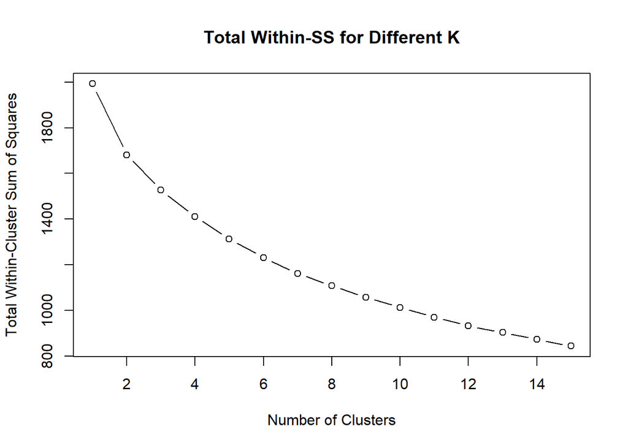

```r
k_check <- 1:15
for (i in 1:15){
  km <- kmeans(pca_data, centers = i, nstart = 100)
  k_check[i] <- km$tot.withinss
}
plot(k_check, type = "b", main = "Total Within-SS for Different K", xlab = "Number of Clusters", ylab = "Total Within-Cluster Sum of Squares")
```

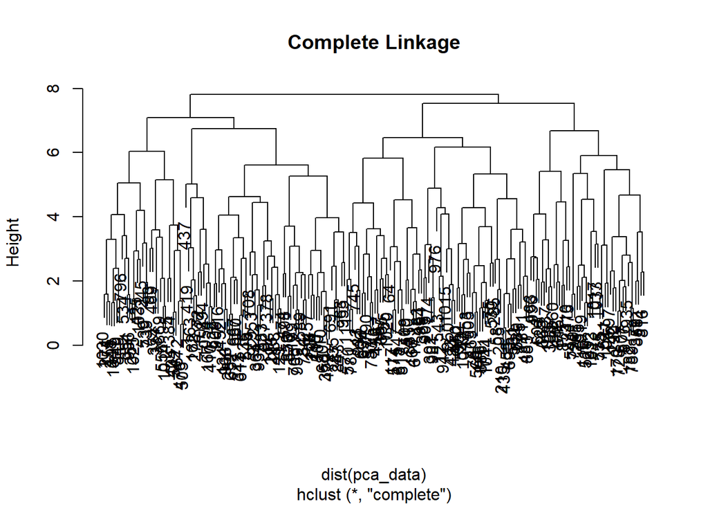

```r
hc_com <- hclust(dist(pca_data), method = "complete")
hc_avg <- hclust(dist(pca_data), method = "average")
hc_sin <- hclust(dist(pca_data), method = "single")

plot(hc_com, main = "Complete Linkage")
```

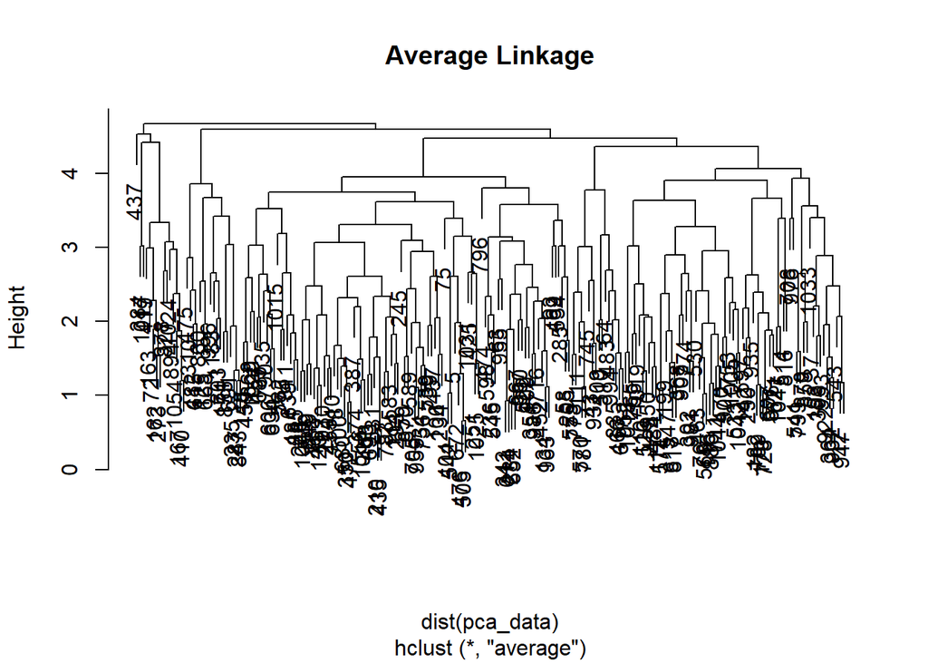

```r
plot(hc_avg, main = "Average Linkage")
```

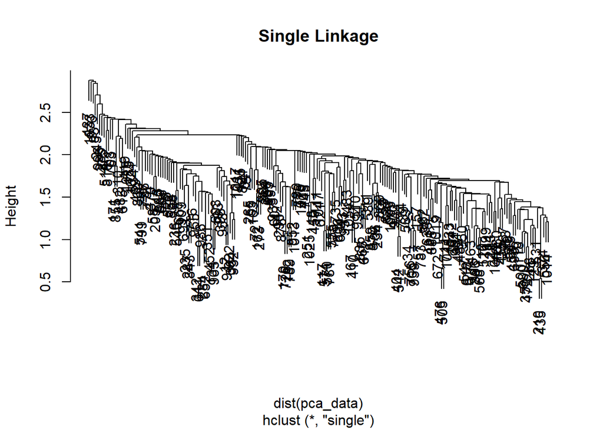

```r
plot(hc_sin, main = "Single Linkage")
```

## Cluster Validation

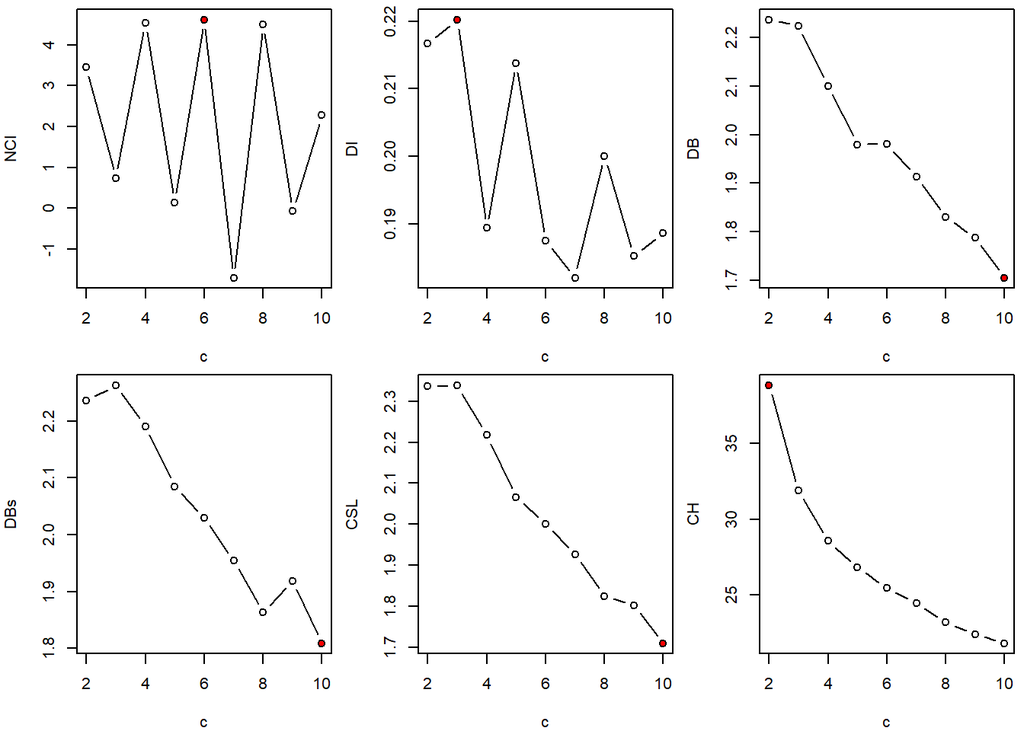

```r
par(mfrow = c(1,1))
plot_idx(cvi_km)
```

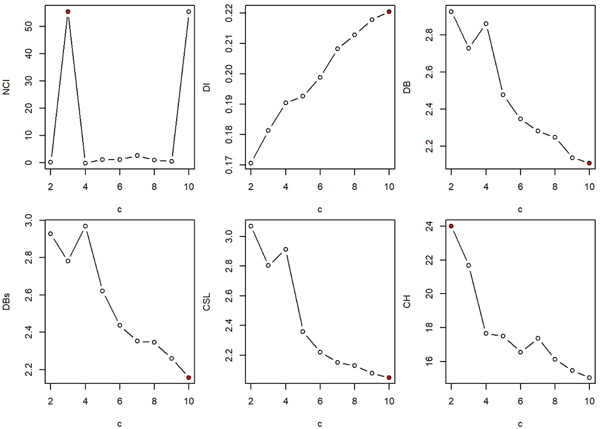

```r
plot_idx(cvi_c)
```

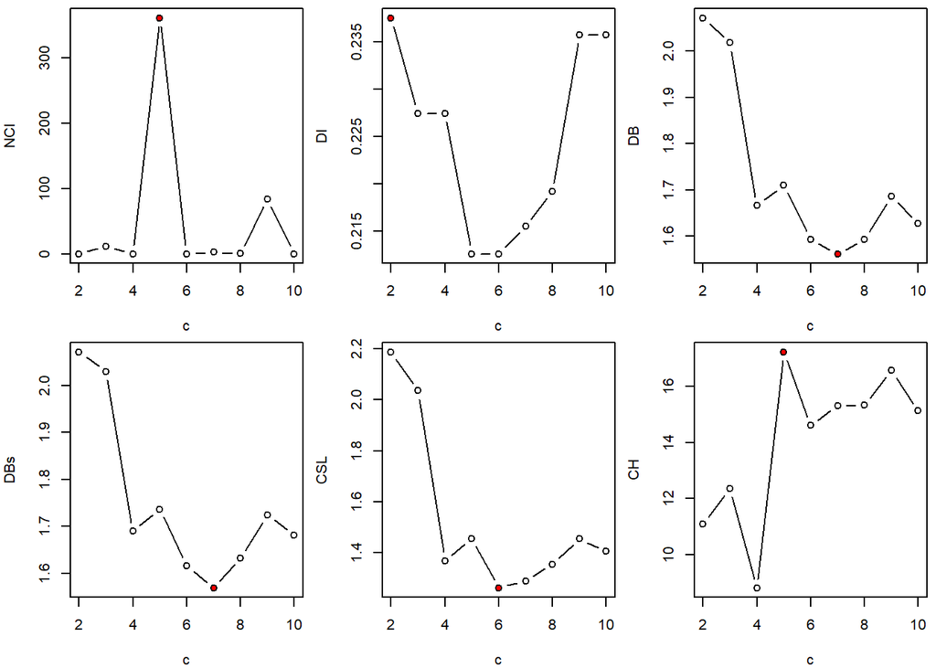

```r
plot_idx(cvi_a)
```

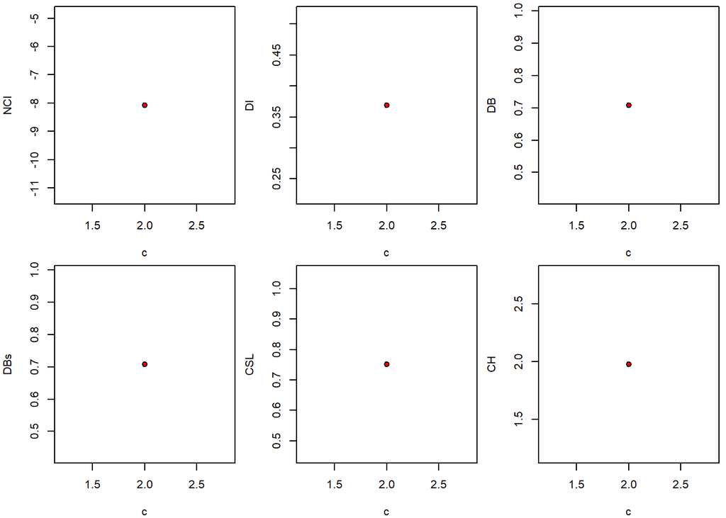

```r
plot_idx(cvi_s)
```

## Cluster Visualization

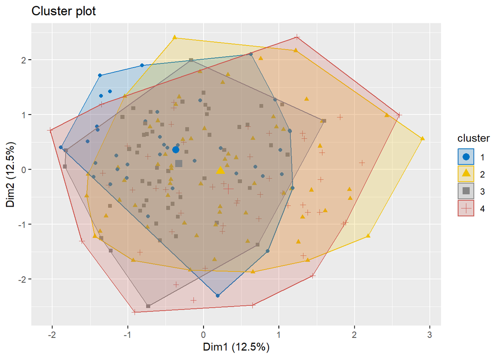

```r
set.seed(123)
k <- 4
kmeans_res <- kmeans(pca_data, centers = k)
fviz_cluster(kmeans_res, data = pca_data, ellipse.type = "convex", geom = "point", palette = "jco")
```

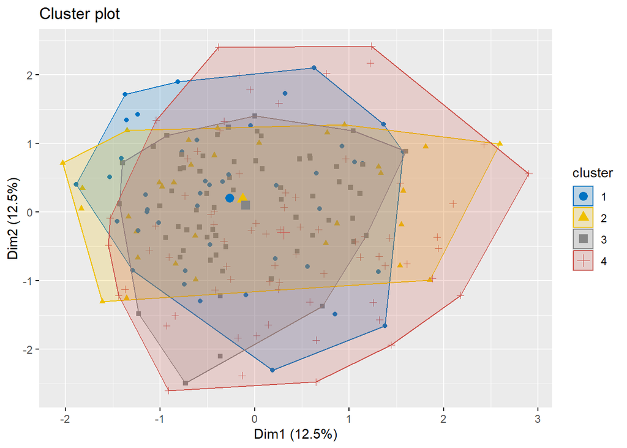

```r
fviz_cluster(list(data = pca_data, cluster = cutree(hc_com, k = 4)), ellipse.type = "convex", geom = "point", palette = "jco")
```

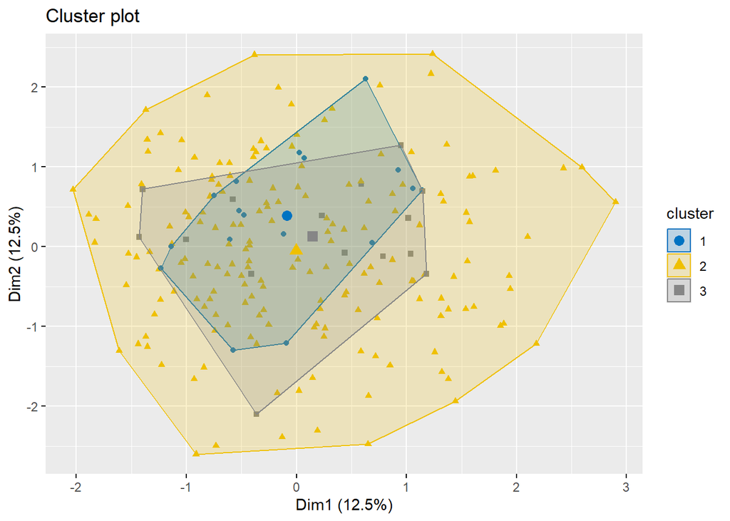

```r
fviz_cluster(list(data = pca_data, cluster = cutree(hc_avg, k = 3)), ellipse.type = "convex", geom = "point", palette = "jco")
```

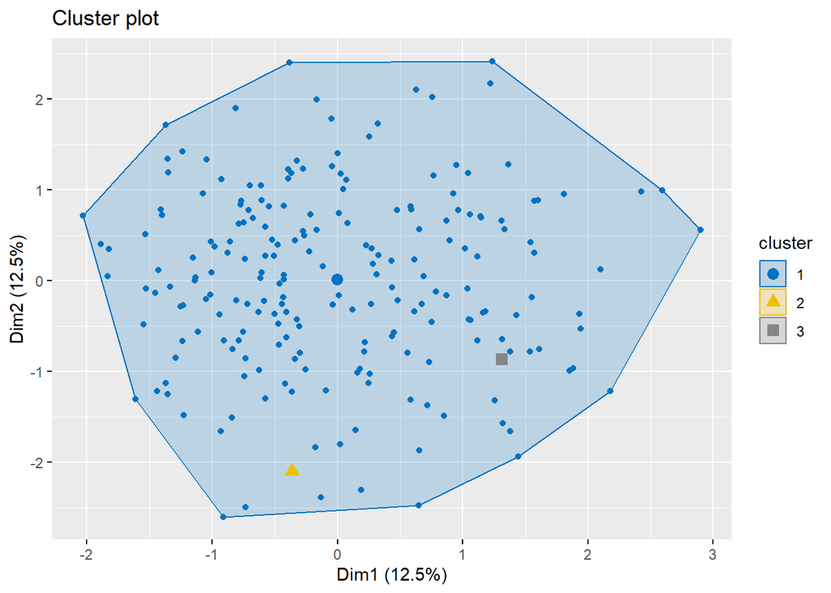

```r
fviz_cluster(list(data = pca_data, cluster = cutree(hc_sin, k = 3)), ellipse.type = "convex", geom = "point", palette = "jco")
```

```r
loadings <- pca_res$rotation[, 1:best_pc]
```

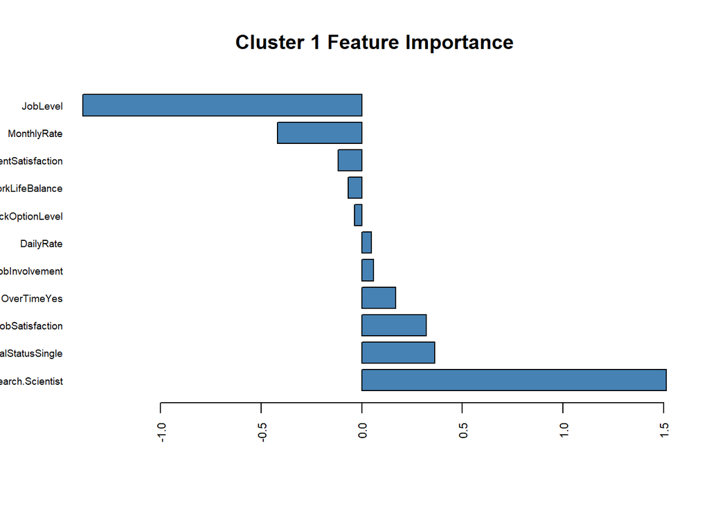

```
## JobRoleResearch.Scientist       MaritalStatusSingle           JobSatisfaction
##                1.51351125                0.36330949                0.31993855
##               OverTimeYes            JobInvolvement                 DailyRate
##                0.16750547                0.05944853                0.04739420
##          StockOptionLevel           WorkLifeBalance   EnvironmentSatisfaction
##               -0.03711820               -0.06684463               -0.11687964
##               MonthlyRate                  JobLevel
##               -0.41790865               -1.38680778
```

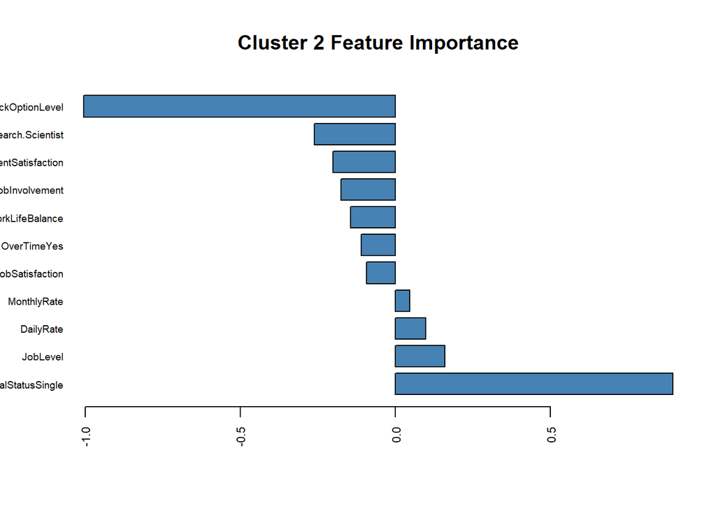

```
##       MaritalStatusSingle                  JobLevel                 DailyRate
##                0.89370194                0.15937866                0.09679504
##               MonthlyRate           JobSatisfaction               OverTimeYes
##                0.04545223               -0.09357094               -0.11083936
##           WorkLifeBalance            JobInvolvement   EnvironmentSatisfaction
##               -0.14437800               -0.17573862               -0.20072379
## JobRoleResearch.Scientist          StockOptionLevel
##               -0.26131097               -1.00449067
```

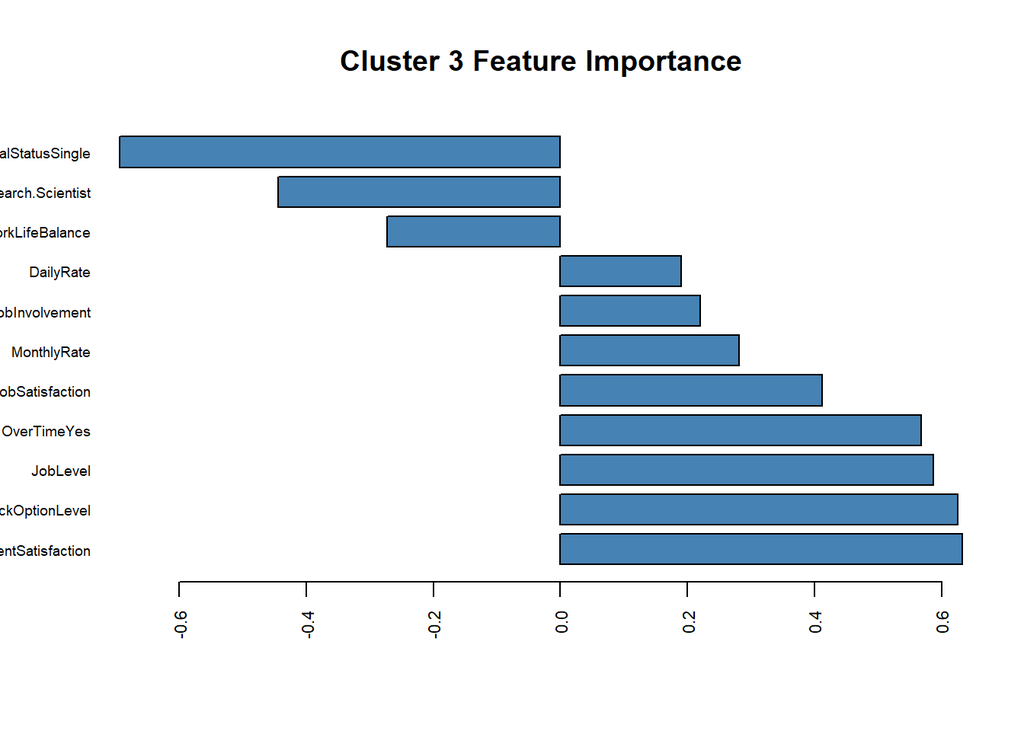

```
##   EnvironmentSatisfaction          StockOptionLevel                  JobLevel
##                 0.6327156                 0.6253720                 0.5873792
##               OverTimeYes           JobSatisfaction               MonthlyRate
##                 0.5677547                 0.4115537                 0.2818229
##            JobInvolvement                 DailyRate           WorkLifeBalance
##                 0.2205989                 0.1906470                -0.2727619
## JobRoleResearch.Scientist       MaritalStatusSingle
##                -0.4440318                -0.6940468
```

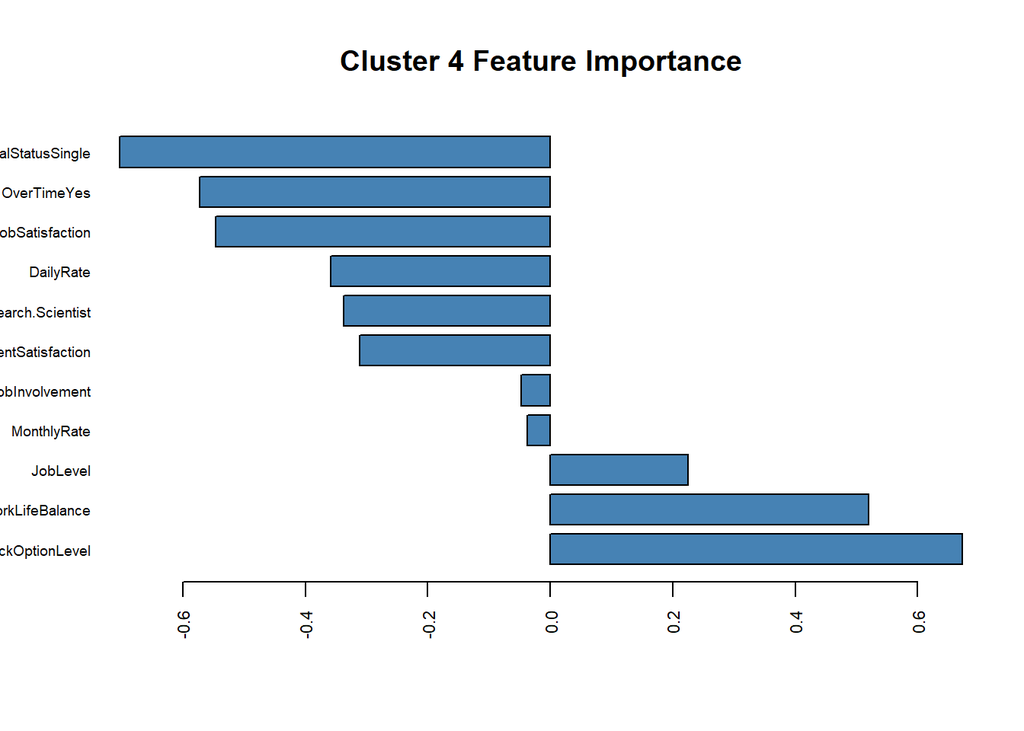

```
##          StockOptionLevel           WorkLifeBalance                  JobLevel
##                0.67266148                0.51941174                0.22478185
##               MonthlyRate            JobInvolvement   EnvironmentSatisfaction
##               -0.03779423               -0.04723736               -0.31076625
## JobRoleResearch.Scientist                 DailyRate           JobSatisfaction
##               -0.33733439               -0.35824188               -0.54677408
##               OverTimeYes       MaritalStatusSingle
##               -0.57240827               -0.70324181
```

```r
centers_pca <- kmeans_res$centers
centers_orig <- centers_pca %*% t(loadings)
centers_orig <- as.data.frame(centers_orig)
rownames(centers_orig) <- paste0("Cluster", 1:nrow(centers_orig))

par(mfrow = c(1, 1))
for (i in 1:4) {
  cluster_values <- centers_orig[paste0("Cluster", i), ]
  cluster_vector <- as.numeric(cluster_values)
  names(cluster_vector) <- colnames(centers_orig)
  sorted_values <- sort(cluster_vector, decreasing = TRUE)

  barplot(height = sorted_values,
          names.arg = names(sorted_values),
          las = 2,
          cex.names = 0.6,
          cex.axis = 0.7,
          main = paste("Cluster", i, "Feature Importance"),
          col = "steelblue",
          space = 0.3,
          horiz = 1)
  print(sorted_values)
}
```

## Class Distribution in Each Cluster

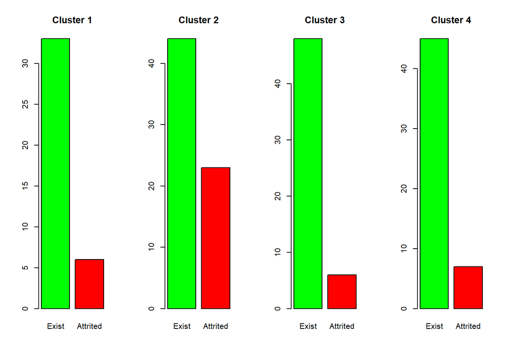

```r
clus1 <- mat_test[kmeans_res$cluster == 1, ]
clus2 <- mat_test[kmeans_res$cluster == 2, ]
clus3 <- mat_test[kmeans_res$cluster == 3, ]
clus4 <- mat_test[kmeans_res$cluster == 4, ]



par(mfrow = c(1,4))

barplot(table(clus1$Attrition), names.arg = c("Exist", "Attrited"), col = c("green","red"), main = "Cluster 1")
barplot(table(clus2$Attrition), names.arg = c("Exist", "Attrited"), col = c("green","red"), main = "Cluster 2")
barplot(table(clus3$Attrition), names.arg = c("Exist", "Attrited"), col = c("green","red"), main = "Cluster 3")
barplot(table(clus4$Attrition), names.arg = c("Exist", "Attrited"), col = c("green","red"), main = "Cluster 4")
```

```r
table(clus1$Attrition)
```

```
##
##  0  1
## 33  6
```

```r
table(clus2$Attrition)
```

```
##
##  0  1
## 44 23
```

```r
table(clus3$Attrition)
```

```
##
##  0  1
## 48  6
```

```r
table(clus4$Attrition)
```

```
##
##  0  1
## 45  7
```

```r
table(clus1$Attrition)[2]/sum(table(clus1$Attrition))
```

```
##         1
## 0.1538462
```

```r
table(clus2$Attrition)[2]/sum(table(clus2$Attrition))
```

```
##         1
## 0.3432836
```

```r
table(clus3$Attrition)[2]/sum(table(clus3$Attrition))
```

```
##         1
## 0.1111111
```

```r
table(clus4$Attrition)[2]/sum(table(clus4$Attrition))
```

```
##         1
## 0.1346154
```

## แปลผลแต่ละกลุ่มเทียบกับ สัดส่วนการลาออกของพนักงานในแต่ละกลุ่ม cluster

### สรุป Cluster ที่ 1

JobRoleResearch.Scientist +1.45 พนักงานในกลุ่มนี้ส่วนใหญ่มีตำแหน่งเป็นนักวิจัย

EnvironmentSatisfaction -0.10 ความพึงพอใจต่อสิ่งแวดล้อมในที่ทำงานต่ำเล็กน้อย

ทำงานในสายวิชาการ/วิจัย (Research Scientist) มักยังไม่มีครอบครัวหรือชีวิตแต่งงาน ทุ่มเทกับงาน (ทำ OT, Job Involvement สูงในระดับหนึ่ง) พึงพอใจกับเนื้องานแม้รายได้และตำแหน่งจะอยู่ในระดับต่ำ จากการที่รายได้และตำแหน่งจะอยู่ในระดับต่ำ แต่ความพึงพอใจและความเชี่ยวชาญเฉพาะตัวในบทบาทที่ตนเองทำ ส่งผลให้มี แรงจูงใจภายใน (intrinsic motivation) สูง ซึ่งสะท้อนถึงแนวโน้มการลาออกที่ต่ำ

### สรุป Cluster ที่ 2

JobLevel +0.154 ตำแหน่งงานในกลุ่มนี้สูงกว่าค่าเฉลี่ย ซึ่งอาจบ่งชี้ถึงประสบการณ์หรือบทบาทสำคัญบางประการ

#### **กลายเป็นกลุ่มที่มีแน้วโน้มที่จะลาออกมากที่สุดจากทั้ง 4 กลุ่ม โดยจะสรุปกลุ่มนี้ในส่วนสุดท้ายของ Report

### สรุป Cluster ที่ 3

MonthlyRate +0.218 รายได้รายเดือนในระดับดี

JobRoleResearch.Scientist -0.385 กลุ่มนี้ไม่ใช่นักวิจัย แสดงถึงตำแหน่งงานที่หลากหลาย

MaritalStatusSingle -0.748 ส่วนใหญ่ มีครอบครัวแล้ว ซึ่งอาจเชื่อมโยงกับความมั่นคงในชีวิต และไม่ต้องการเปลี่ยนงานบ่อย

มีรายได้และสิทธิประโยชน์สูง (รวมถึงหุ้น) มีความพึงพอใจในสิ่งแวดล้อมและเนื้องาน อยู่ในตำแหน่งที่มั่นคง และยินดีทำ OT ส่วนใหญ่ มีครอบครัวแล้ว ซึ่งอาจต้องการความมั่นคง และหลีกเลี่ยงการเปลี่ยนงาน พฤติกรรมโดยรวมสะท้อนถึงกลุ่มที่ “มั่นคงในองค์กร” ทั้งในเชิงเศรษฐกิจและจิตใจ

### สรุป Cluster ที่ 4

JobLevel +0.253 ตำแหน่งงานระดับปานกลางถึงสูง บ่งชี้ถึงสถานภาพที่มั่นคงในองค์กร

JobRoleResearch.Scientist -0.367 ส่วนใหญ่ไม่ใช่พนักงานฝ่ายวิจัย

# สรุปผลสุดท้าย

โดยสรุป พนักงานในกลุ่มที่ 2 เผชิญกับสภาวะการณ์ที่เกิดจากปัจจัยเชิงลบหลายประการร่วมกัน ได้แก่ ความไม่พึงพอใจในลักษณะงานที่ปฏิบัติ การขาดความผูกพันต่อองค์กร การรับรู้ว่าผลตอบแทนโดยรวม (โดยเฉพาะส่วนของหุ้น) ไม่สอดคล้องกับความคาดหวัง และความไม่พึงพอใจต่อสภาพแวดล้อมในการทำงาน ปัจจัยเหล่านี้ เมื่อประกอบกับสถานภาพโสดซึ่งเพิ่มความคล่องตัวในการเปลี่ยนแปลงงาน ส่งผลให้พนักงานกลุ่มนี้มีอัตราการลาออกสูงที่สุดอย่างมีนัยสำคัญลาออกสูงที่สุดอย่างมีนัยสำคัญ